# HousePrice Prediction

# Adding Indicator Variable

```r
summary(filtered_data2_model3)
```

```
Call:
lm(formula = SalePrice ~ GrLivArea + Neighborhood, data = filtered_data2)

Residuals:
     Min       1Q   Median       3Q      Max
-0.72516 -0.10671  0.02293  0.11654  0.78654

Coefficients:
                    Estimate Std. Error t value Pr(>|t|)
(Intercept)          7.68389    0.23425  32.802  < 2e-16 ***
GrLivArea            0.56794    0.03309  17.162  < 2e-16 ***
NeighborhoodEdwards -0.01822    0.03247  -0.561    0.575
NeighborhoodNAmes    0.13157    0.02900   4.537 7.68e-06 ***
---
Signif. codes:  0 ‘***’ 0.001 ‘**’ 0.01 ‘*’ 0.05 ‘.’ 0.1 ‘ ’ 1

Residual standard error: 0.1957 on 378 degrees of freedom
Multiple R-squared:  0.4916,    Adjusted R-squared:  0.4875
F-statistic: 121.8 on 3 and 378 DF,  p-value: < 2.2e-16
```

# Adding interaction variables

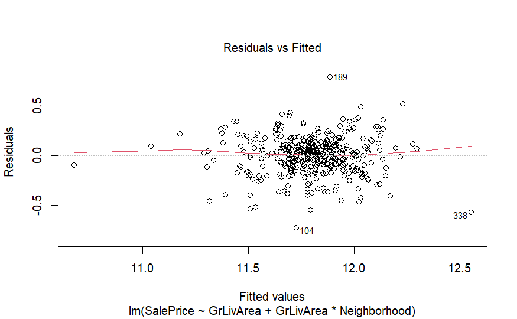

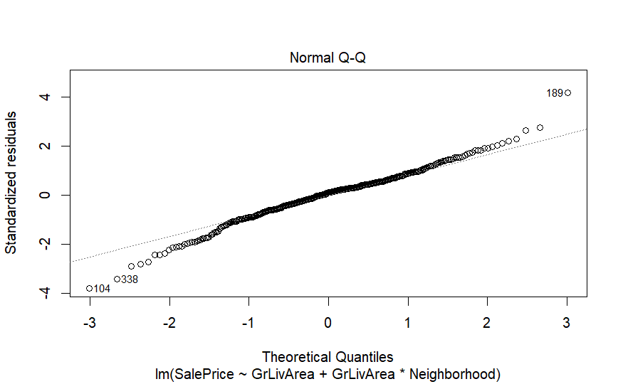

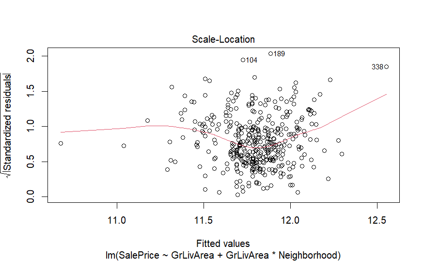

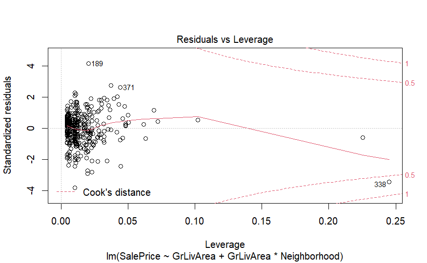

## Anova Analysis

```r
#ANOVA for model without Neighborhood
anova(filtered_data2_model)
```

```
Analysis of Variance Table

Response: SalePrice
           Df Sum Sq Mean Sq F value                Pr(>F)
GrLivArea   1 12.008 12.0084  276.32 < 0.00000000000000022 ***
Residuals 381 16.558  0.0435
---
Signif. codes:  0 ‘***’ 0.001 ‘**’ 0.01 ‘*’ 0.05 ‘.’ 0.1 ‘ ’ 1
```

# Model with Interaction Summaries

#### For each neighborhood, the regression model predicting SalePrice using GrLivArea is given by:

#### Neighborhood ‘BrkSide’:

logSalePrice = 5.91292 + 0.81965*logGrLivArea

##### Interpretation of the Coefficients

Every time the square footage of the living area doubles, there is an estimated multiplicative increase of 1.76497775436 (about 76.5% increase) in the median Sale Price.

When the square footage of the living area is 0, the estimated median SalePrice 369.78435.

##### Interpretation of Confidence Intervals

Every time the square footage of the living area doubles, the estimated multiplicative increase in median Sales Price for Brookeside is between 1.60081478829 and 1.94597031156.

When the square footage of the living area is 0., the estimated median Sale Price is between 137.10639085 and 997.332584908 in Brookside neighborhood.

#### Neighborhood ‘NAmes’:

logSalePrice = 7.74784 + 0.47303*logGrLivArea

##### Interpretation of the Coefficients

Every time the square footage of the living area doubles, there is an estimated multiplicative increase of 1.38802158181, (about 38.8% increase) in the median Sale Price.

#### Neighborhood ‘Edwards’:

logSalePrice = 8.00651 + 0.51967 *logGrLivArea

##### Interpretation of the Coefficients

Every time the square footage of the living area doubles, there is an estimated multiplicative increase of 1.4336074105 (about 43.36% increase) in the median Sale Price.

When the square footage of the living area is 0, the estimated median Sale Price 3000.42732748.

##### Confidence Intervals and Interpretation

When the square footage of the living area is 0, the estimated median Sale Price is between 312.416333335 and 28815.756004 for houses in the Edwards Neighborhood.

Every time the square footage of the living area doubles, the estimated multiplicative increase in median Sales Price for Edwards Neighborhood is between 1.14827731299 and 1.78988066094.